# Factores clínicos asociados a la enfermedad cardiovascular

Una evaluación mediante el Factor de Bayes

César Salazar · Gerardo Montero · Gabriel Robles · Óscar Espinoza

CA-0303 Estadística Actuarial I · Grupo 5 Alpha Epsilon

2026-07-07

## ¿Por qué este estudio?

- ECV = **primera causa de muerte** mundial.
- Con muestras grandes, las pruebas frecuentistas **siempre rechazan** $H_0$.
- El **Factor de Bayes** cuantifica *cuánta* evidencia hay, no solo si es “significativa”.

$$\text{BF}_{10} = \frac{P(\mathbf{y} \mid H_1)}{P(\mathbf{y} \mid H_0)}$$

## Pregunta y objetivos

> ¿Qué tan fuerte es la evidencia de que la presión arterial y la acumulación de factores de riesgo se asocian con la ECV?

| # | Contraste |
| --- | --- |
| H1 | $\mu_\text{sistólica}$ difiere entre grupos |
| H2 | $\mu_\text{diastólica}$ difiere entre grupos |
| H3 | $\rho(\text{índice}, \text{ECV}) \neq 0$ |
| H4 | $P(\text{ECV} \mid k{=}0) \neq P(\text{ECV} \mid k{\geq}3)$ |

## Datos

- Kaggle: **70 000** → filtrado → **68 474**
- Prevalencia ECV: **49,5%** (vs. 5–15% poblacional)

| Variable | Sin ECV | Con ECV |
| --- | --- | --- |
| P. sistólica | 119,6 ± 15,1 | 133,9 ± 22,6 |
| P. diastólica | 78,1 ± 9,1 | 84,6 ± 11,5 |
| Edad | 51,4 ± 6,8 | 54,4 ± 6,5 |
| IMC | 27,3 ± 5,2 | 28,7 ± 5,7 |

## Gradiente de riesgo acumulado

Índice $k$: suma de 4 factores binarios.

- Hipertensión
- Obesidad
- Colesterol elevado
- Edad $\geq$ 55

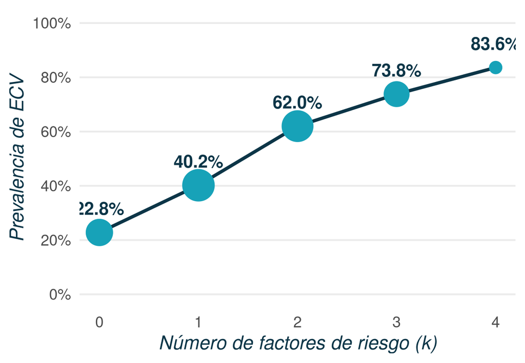

## Metodología

#### Factor de Bayes JZS

$$\text{BF}_{10} = \frac{P(\mathbf{y} \mid H_1)}{P(\mathbf{y} \mid H_0)}, \qquad
P(\mathbf{y} \mid H_1) = \int P(\mathbf{y} \mid \theta, H_1)\, \pi(\theta)\, d\theta$$

- `ttestBF()` → H1, H2, H4
- `correlationBF()` → H3
- Previa Cauchy: $r = \frac{\sqrt{2}}{2}$
- 10 000 iteraciones MCMC

#### Escala de Jeffreys

| $\text{BF}_{10}$ | Evidencia |
| --- | --- |
| 1 – 3 | Anecdótica |
| 3 – 10 | Moderada |
| 10 – 100 | Fuerte |
| > 100 | **Extrema** |

## Resultados: evidencia

| Prueba | $\log_{10}(\text{BF}_{10})$ | Evidencia |
| --- | --- | --- |
| P. sistólica | **3 010** | Extrema |
| P. diastólica | **1 833** | Extrema |
| Correlación gradiente | **204** | Extrema |
| Extremos ($k{=}0$ vs $k{\geq}3$) | **2 351** | Extrema |

Las cuatro hipótesis: evidencia **extrema** a favor de $H_1$.

## Resultados: magnitud

### Presión arterial

|  | $\Delta\mu$ | IC 95% |
| --- | --- | --- |
| Sistólica | **+14,28** | [13,89 ; 14,67] |
| Diastólica | **+6,42** | [6,17 ; 6,67] |

*Unidades: mmHg*

### Correlación

$\hat{\rho} = 0{,}329$ · IC: $[0{,}303 ; 0{,}355]$

### Extremos del gradiente

- $k{=}0$: prevalencia **22,8%**
- $k{\geq}3$: prevalencia **77,1%**
- $d = 1{,}424$ (efecto **grande**)

. . .

→ Un asegurado con 4 factores tiene **3,7×** más prevalencia que uno con 0.

## Resultados: robustez y prevalencia

### Sensibilidad a la previa

Variación entre escalas *medium*, *wide*, *ultrawide*:

**Rango máximo: 0,108** en $\log_{10}$

→ Despreciable frente a

$10^{204}$ – $10^{3010}$.

La evidencia **no depende** de la previa elegida.

### Prevalencia Beta-Bernoulli

$\hat{\theta} = 0{,}4948$, IC: $[0{,}4911 ; 0{,}4986]$

$$P(\theta \leq 0{,}15 \mid \mathbf{y}) \approx 0$$

→ El 49,5% de ECV es **real**, no aleatorio.

→ Resultados válidos **internamente**, no extrapolables.

## Conclusiones

1. Evidencia **extrema** en las 4 hipótesis

($\log_{10}\text{BF} \geq 204$).

2. Efectos con **interpretación práctica**: +14 mmHg sistólica, $d = 1{,}4$ en el gradiente.
3. Gradiente útil para **estratificación actuarial**: 22,8% → 83,6%.

### Limitaciones

- Prevalencia atípica (49,5%)
- Peso uniforme en el índice

### Trabajo futuro

- Cohorte con prevalencia documentada
- Regresión logística bayesiana

## Referencias

Armero, C., Rodríguez Y, P., & Torre Hernández, J. M. D. L. (2022). Una pequeña mirada a la estadística bayesiana en el análisis de datos cardiológicos. *REC: interventional cardiology*, 8378. https://doi.org/10.24875/RECIC.M22000284

D’Agostino, R. B., Pencina, M. J., Massaro, J. M., & Coady, S. (2013). Cardiovascular Disease Risk Assessment: Insights from Framingham. *Global Heart*, *8*(1), 11-23. https://doi.org/10.1016/j.gheart.2013.01.001

Damen, J. A. A. G., Hooft, L., Schuit, E., Debray, T. P. A., Collins, G. S., Tzoulaki, I., Lassale, C. M., Siontis, G. C. M., Chiocchia, V., Roberts, C., Schlüssel, M. M., Gerry, S., Black, J. A., Heus, P., Van Der Schouw, Y. T., Peelen, L. M., & Moons, K. G. M. (2016). Prediction models for cardiovascular disease risk in the general population: systematic review. *BMJ*, i2416. https://doi.org/10.1136/bmj.i2416

DeGroot, M., & Schervish, M. (2012). *Probability & Statistics* (4.ª ed.). Pearson. https://tinyurl.com/3s8k98yc

Eiseman, N. A., Bianchi, M. T., & Westover, M. B. (2014). The Information Theoretic Perspective on Medical Diagnostic Inference. *Hospital Practice*, *42*(2), 125-138. https://doi.org/10.3810/hp.2014.04.1110

Gill, C. J., Sabin, L., & Schmid, C. H. (2005). Why clinicians are natural bayesians. *BMJ*, *330*(7499), 1080-1083. https://doi.org/10.1136/bmj.330.7499.1080

Kaufmann, T., Castela Forte, J., Hiemstra, B., Wiering, M. A., Grzegorczyk, M., Epema, A. H., Van Der Horst, I. C. C., & SICS Study Group. (2019). A Bayesian Network Analysis of the Diagnostic Process and its Accuracy to Determine How Clinicians Estimate Cardiac Function in Critically Ill Patients: Prospective Observational Cohort Study. *JMIR Medical Informatics*, *7*(4), e15358. https://doi.org/10.2196/15358

Lorca, J. C., & Águila, L. C. (2024). Inferencia Bayesiana en el proceso de diagnóstico clínico: un enfoque docente para la toma de decisiones. *Revista Chilena de Infectología*, *41*(6), 762-768. https://doi.org/10.4067/s0716-10182024000600168

Pek, T., & Van Zandt, T. (2019). Frequentist and Bayesian approaches to to data analysis: Evaluation and estimation. *SageJournals*, *19*(1). https://doi.org/10.1177/1475725719874542

Ramos-Vera, C. A. (2021). El uso del factor Bayes en la investigación clínica de cardiología. *Revista Española de Cardiología*, *74*(7), 641-642. https://doi.org/10.1016/j.recesp.2021.01.013

Real Academia Española. (2026). *Diccionario de la lengua española*. https://dle.rae.es

Rodríguez-Escudero, J. P., López-Jiménez, F., & Trejos-Gutiérrez, J. (2012). Cardiología "basada en la evidencia": aplicaciones prácticas de la epidemiología. IV. Modelos de predicción de riesgo cardiovascular. *Arch. Cardiol. Méx*, *82*(1). https://www.scielo.org.mx/scielo.php?script=sci_arttext&pid=S1405-99402012000100011

Ulianova, S. (2019). *Cardiovascular Disease Dataset*. https://www.kaggle.com/datasets/sulianova/cardiovascular-disease-dataset

Visseren, F. L. J., Mach, F., Smulders, Y. M., Carballo, D., Koskinas, K. C., Bäck, M., et al. (2021). 2021 ESC Guidelines on cardiovascular disease prevention in clinical practice. *European Heart Journal*, *42*(34), 3227-3337. https://doi.org/10.1093/eurheartj/ehab484

World Health Organization. (2000). *Obesity: Preventing and Managing the Global Epidemic* (WHO Technical Report Series 894). World Health Organization. https://apps.who.int/iris/handle/10665/42330

World Health Organization, & International Society of Hypertension. (2020). *WHO/ISH Global Hypertension Practice Guidelines*. World Health Organization. https://www.who.int/publications/i/item/9789240015111

World Heart Federation. (2023). *Enfermedades cardiovasculares (ECV)*. https://world-heart-federation.org/es/what-is-cvd/